# MANOVA

Multiple numerical Vs. categorical

[Dr. Peng Zhao](https://connect.xjtlu.edu.cn/user/pengzhao) (✉ peng.zhao@xjtlu.edu.cn)

Department of Health and Environmental Sciences  
Xi’an Jiaotong-Liverpool University

# 1 Learning objectives

1. What is one-way and two-way MANOVA.
2. The hypotheses and usages of MANOVA.
3. The meanings of the assumptions of MANOVA.

# 2 Principle

## 2.1 Definition

**Univariate Analysis of Variance (ANOVA):**

one dependent variable (continuous) ~ one or multiple independent variables (categorical).

**Multivariate Analysis of Variance (MANOVA):**

multiple dependent variables (continuous) ~ one or multiple independent variables (categorical). Comparing multivariate sample means. It uses the covariance between outcome variables in testing the statistical significance of the mean differences when there are multiple dependent variables.

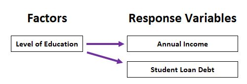

Hypothesis:

- *H*<sub>0</sub>: the group mean vectors are the same for all groups (the levels of the categorical variable has no influence on the numerical variables)

## 2.2 Why MANOVA

- Reduce the Type I error
- Control for inter-correlations among the multiple dependent variables
- Uses more information from the dependent variables i.e., MANOVA may find differences between groups based on combined information from the multiple dependent variables.

Example: Influence of teaching methods on student satisfaction scores and exam scores[^1].

<sup>1</sup> https://statisticsbyjim.com/anova/multivariate-anova-manova-benefits-use/

```r
dtf <- read.csv('data/teaching_methods.csv')
summary(aov(Test ~ Method, data = dtf))
```

```
            Df   Sum Sq   Mean Sq F value Pr(>F)
Method       1 0.000578 0.0005780   2.426  0.126
Residuals   46 0.010958 0.0002382
```

```r
summary(aov(Satisfaction ~ Method, data = dtf))
```

```
            Df   Sum Sq   Mean Sq F value Pr(>F)
Method       1 0.000032 0.0000320   0.135  0.715
Residuals   46 0.010944 0.0002379
```

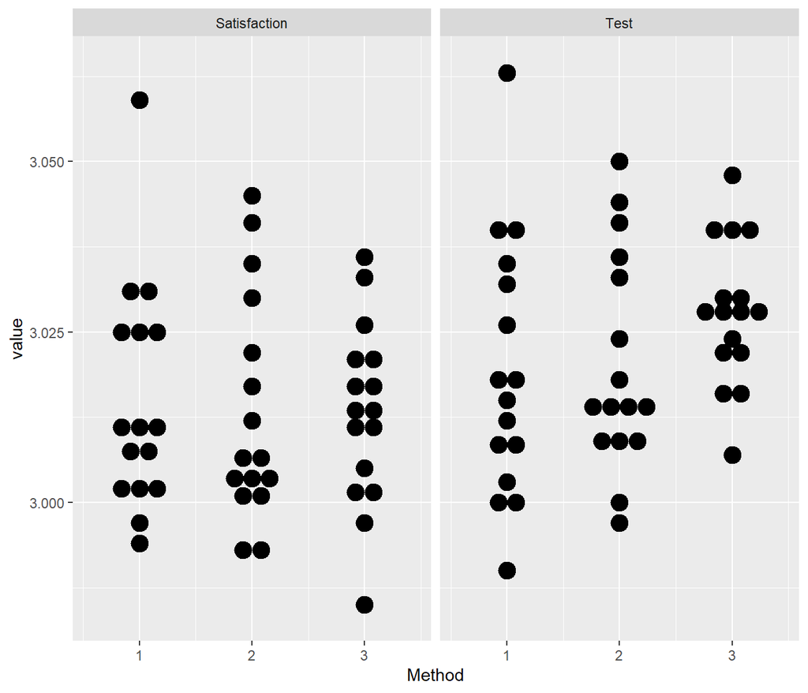

```r
library(ggplot2)
library(tidyr)
dtf |>
  pivot_longer(-Method) |>
  ggplot() +
  geom_dotplot(aes(x = Method, y = value, group = Method), binaxis = "y", stackdir = "center") +
  facet_wrap(name~.)
```

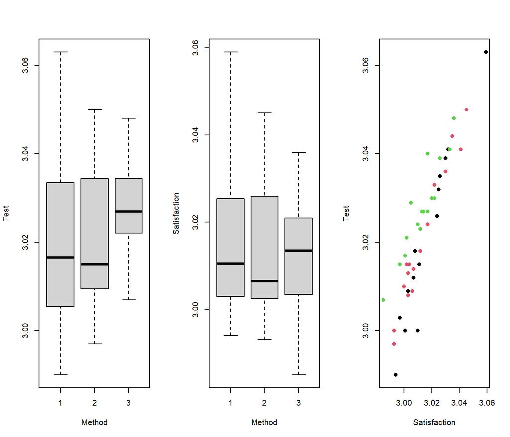

```r
par(mfrow = c(1, 3))
boxplot(Test ~ Method, data = dtf)
boxplot(Satisfaction ~ Method, data = dtf)
plot(dtf$Satisfaction, dtf$Test, col = dtf$Method, pch = 16, xlab = 'Satisfaction', ylab = 'Test')
```

```r
tm_manova <- manova(cbind(dtf$Test, dtf$Satisfaction) ~ dtf$Method)
summary(tm_manova)
```

```
           Df  Pillai approx F num Df den Df   Pr(>F)
dtf$Method  1 0.45766   18.987      2     45 1.05e-06 ***
Residuals  46
---
Signif. codes:  0 '***' 0.001 '**' 0.01 '*' 0.05 '.' 0.1 ' ' 1
```

Hypothesis test: F-test, converted from

- Pillai’s Trace test (most robust to departures from assumptions),
- Wilk’s Lambda test
- Roy’s Largest Root test
- Hotelling-Lawley’s test

## 2.3 Assumptions

- Multivariate normality
- Homogeneity of the variance-covariance matrix

- No outliers in dependent variables
- Linearly relation for each group of the independent variables
- No multicollinearity among dependent variables

# 3 One-way MANOVA

Multiple dependent numerical variables ~ one independent categorical variable

Example: The iris dataset. Do the species have influence on the sepal size?

Visualization:

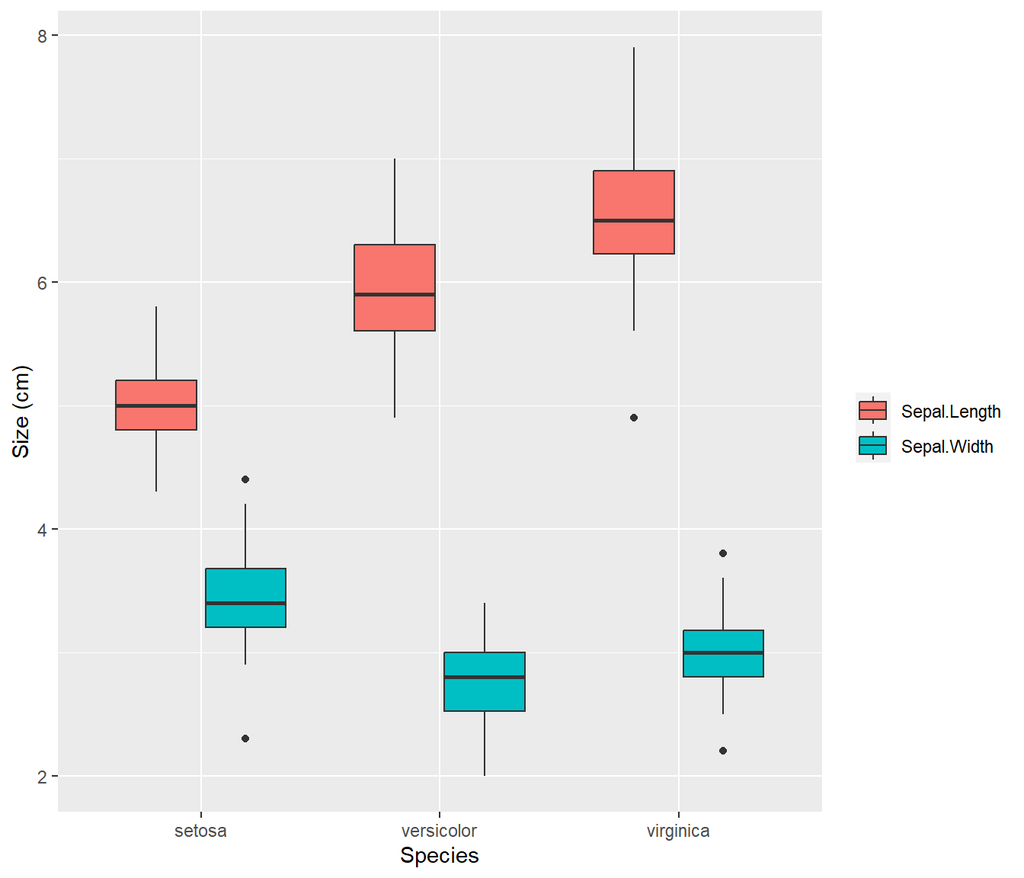

```r
library(ggplot2)
library(tidyr)
iris[, c('Species', 'Sepal.Length', 'Sepal.Width')] |>
  pivot_longer(cols = c(Sepal.Length, Sepal.Width)) |>
  ggplot() +
  geom_boxplot(aes(Species, value, fill = name)) +
  labs(y = 'Size (cm)', fill = '')
```

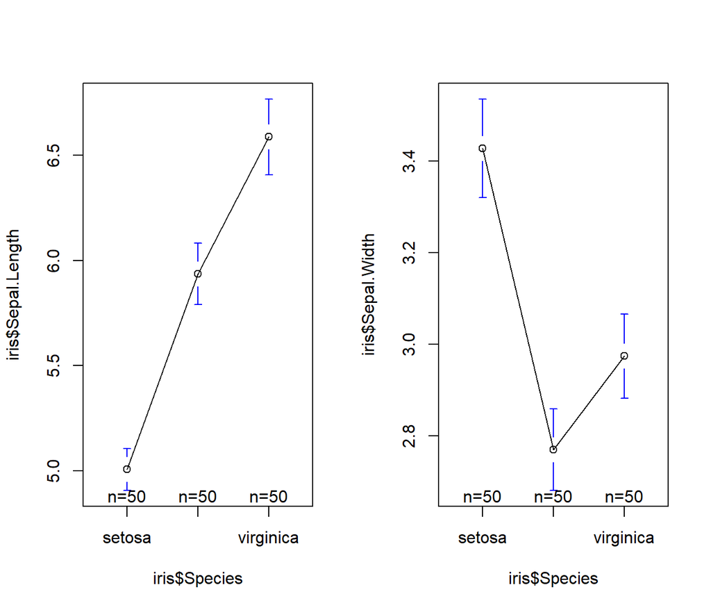

```r
library(gplots)
par(mfrow = c(1, 2))
plotmeans(iris$Sepal.Length ~ iris$Species)
plotmeans(iris$Sepal.Width ~ iris$Species)
```

1. Hypothesis:
- *H*<sub>0</sub>: The population means of the sepal length and the sepal width are not different across the species.
2. Collect data

```r
# multivariate normality test
SepalSize <- cbind(iris$Sepal.Length, iris$Sepal.Width)
# or
SepalSize <- as.matrix(iris[, c('Sepal.Length', 'Sepal.Width')])
```

3. Calculate the test statistic: the Pillai’s Trace test or the F-test

```r
iris_manova <- manova(SepalSize ~ iris$Species)
summary(iris_manova)
```

```
              Df  Pillai approx F num Df den Df    Pr(>F)
iris$Species   2 0.94531   65.878      4    294 < 2.2e-16 ***
Residuals    147
---
Signif. codes:  0 '***' 0.001 '**' 0.01 '*' 0.05 '.' 0.1 ' ' 1
```

```r
summary(iris_manova, test = 'Pillai')
```

```
              Df  Pillai approx F num Df den Df    Pr(>F)
iris$Species   2 0.94531   65.878      4    294 < 2.2e-16 ***
Residuals    147
---
Signif. codes:  0 '***' 0.001 '**' 0.01 '*' 0.05 '.' 0.1 ' ' 1
```

```r
summary(iris_manova, test = 'Wilks')
```

```
              Df   Wilks approx F num Df den Df    Pr(>F)
iris$Species   2 0.16654   105.88      4    292 < 2.2e-16 ***
Residuals    147
---
Signif. codes:  0 '***' 0.001 '**' 0.01 '*' 0.05 '.' 0.1 ' ' 1
```

```r
summary(iris_manova, test = 'Roy')
```

```
              Df    Roy approx F num Df den Df    Pr(>F)
iris$Species   2 4.1718   306.63      2    147 < 2.2e-16 ***
Residuals    147
---
Signif. codes:  0 '***' 0.001 '**' 0.01 '*' 0.05 '.' 0.1 ' ' 1
```

```r
summary(iris_manova, test = 'Hotelling-Lawley')
```

```
              Df Hotelling-Lawley approx F num Df den Df    Pr(>F)
iris$Species   2           4.3328   157.06      4    290 < 2.2e-16 ***
Residuals    147
---
Signif. codes:  0 '***' 0.001 '**' 0.01 '*' 0.05 '.' 0.1 ' ' 1
```

Univariate ANOVAs for each dependent variable:

```r
summary.aov(iris_manova)
```

```
 Response Sepal.Length :
              Df Sum Sq Mean Sq F value    Pr(>F)
iris$Species   2 63.212  31.606  119.26 < 2.2e-16 ***
Residuals    147 38.956   0.265
---
Signif. codes:  0 '***' 0.001 '**' 0.01 '*' 0.05 '.' 0.1 ' ' 1

 Response Sepal.Width :
              Df Sum Sq Mean Sq F value    Pr(>F)
iris$Species   2 11.345  5.6725   49.16 < 2.2e-16 ***
Residuals    147 16.962  0.1154
---
Signif. codes:  0 '***' 0.001 '**' 0.01 '*' 0.05 '.' 0.1 ' ' 1
```

Conclusion: The species has a statistically significant effect on the sepal width and sepal length.

# 4 Post-hoc test

After MANOVA gives a significant result, which group(s) is/are different from other(s)?

Linear Discriminant Analysis (LDA)

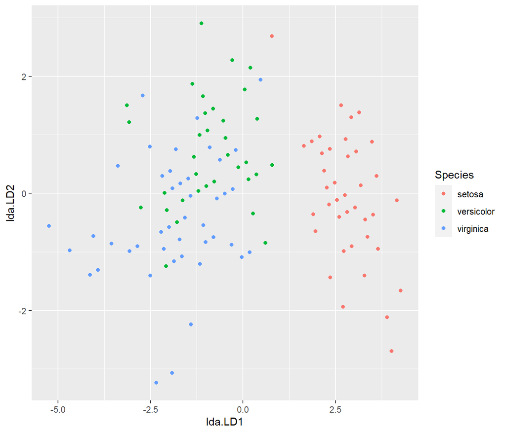

```r
library(MASS)
iris_lda <- lda(iris$Species ~ SepalSize, CV = FALSE)

plot_lda <- data.frame(Species = iris$Species,
                       lda = predict(iris_lda)$x)
ggplot(plot_lda) +
  geom_point(aes(x = lda.LD1, y = lda.LD2, colour = Species))
```

Conclusion: The sepal size of the setosa species is different from other species.

# 5 Test the assumptions

## 5.1 Multivariate normality

**Univariate normality: Shapiro-Wilk test**

- *H*<sub>0</sub>: The variable follows a normal distribution.

```r
tapply(iris$Sepal.Length, iris$Species, shapiro.test)
```

```
$setosa

    Shapiro-Wilk normality test

data:  X[[i]]
W = 0.9777, p-value = 0.4595


$versicolor

    Shapiro-Wilk normality test

data:  X[[i]]
W = 0.97784, p-value = 0.4647


$virginica

    Shapiro-Wilk normality test

data:  X[[i]]
W = 0.97118, p-value = 0.2583
```

```r
tapply(iris$Sepal.Width, iris$Species, shapiro.test)
```

```
$setosa

    Shapiro-Wilk normality test

data:  X[[i]]
W = 0.97172, p-value = 0.2715


$versicolor

    Shapiro-Wilk normality test

data:  X[[i]]
W = 0.97413, p-value = 0.338


$virginica

    Shapiro-Wilk normality test

data:  X[[i]]
W = 0.96739, p-value = 0.1809
```

```r
library(rstatix)
iris |>
  group_by(Species) |>
  shapiro_test(Sepal.Length, Sepal.Width)
```

```
# A tibble: 6 × 4
  Species    variable     statistic     p
  <fct>      <chr>            <dbl> <dbl>
1 setosa     Sepal.Length     0.978 0.460
2 setosa     Sepal.Width      0.972 0.272
3 versicolor Sepal.Length     0.978 0.465
4 versicolor Sepal.Width      0.974 0.338
5 virginica  Sepal.Length     0.971 0.258
6 virginica  Sepal.Width      0.967 0.181
```

Tip:

- If the sample size is large (say n > 50), the visual approaches such as QQ-plot and histogram will be better for assessing the normality assumption.

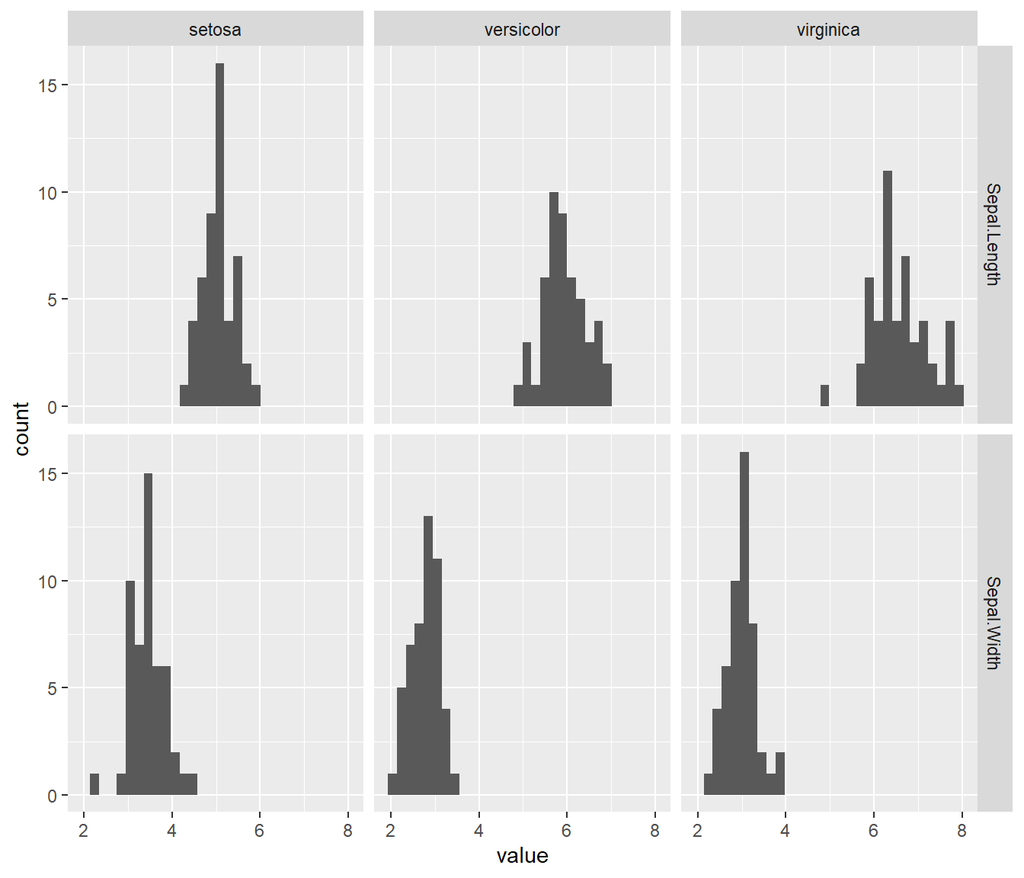

```r
iris[, c('Species', 'Sepal.Length', 'Sepal.Width')] |>
  pivot_longer(cols = c(Sepal.Length, Sepal.Width)) |>
  ggplot() +
  geom_histogram(aes(value)) +
  facet_grid(name ~ Species)
```

Conclusion: As $p > 0.05$, the sepal length and the width for each species are normally distributed.

**Multivariate normality: Mardia’s skewness and kurtosis test**

- *H*<sub>0</sub>: The variables follow a multivariate normal distribution.

```r
library(mvnormalTest)
mardia(iris[, c('Sepal.Length', 'Sepal.Width')])$mv.test
```

```
          Test Statistic p-value Result
1     Skewness    9.4614  0.0505    YES
2     Kurtosis    -0.691  0.4896    YES
3 MV Normality      <NA>    <NA>    YES
```

Conclusion: As $p > 0.05$, the sepal length and the width follow a multivariate normal distribution.

Tip:

- When n > 20 for each combination of the independent and dependent variable, the multivariate normality can be assumed (Multivariate Central Limit Theorem).

## 5.2 Homogeneity of the variance-covariance matrix

**Box’s M test**: Use a lower $\alpha$ level such as $\alpha = 0.001$ to assess the p value for significance.

Hypothesis:

- *H*<sub>0</sub>: The variance-covariance matrices are equal for each combination formed by each group in the independent variable.

```r
library(biotools)
boxM(iris[, c('Sepal.Length', 'Sepal.Width')], iris$Species)
```

```
    Box's M-test for Homogeneity of Covariance Matrices

data:  iris[, c("Sepal.Length", "Sepal.Width")]
Chi-Sq (approx.) = 35.655, df = 6, p-value = 3.217e-06
```

Conclusion: As $p < 0.001$, the variance-covariance matrices for the sepal length and width are not equal for each combination formed by each species.

Which variable fails in equal variance? Use the Bartlett’s or Levene’s test for testing the homogeneity of variance assumption.

## 5.3 Multivariate outliers

- MANOVA is highly sensitive to outliers and may produce Type I or II errors.
- Multivariate outliers can be detected using the Mahalanobis Distance test. The larger the Mahalanobis Distance, the more likely it is an outlier.

```r
library(rstatix)
iris_outlier <- mahalanobis_distance(iris[, c('Sepal.Length', 'Sepal.Width')])
```

## 5.4 Linearity

Visualize the pairwise scatterplot for the dependent variable for each group:

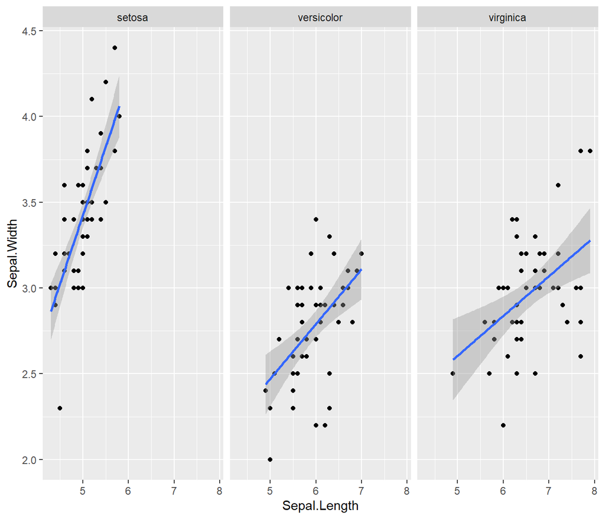

```r
ggplot(iris, aes(x = Sepal.Length, y = Sepal.Width)) +
  geom_point() +
  geom_smooth(method = 'lm') +
  facet_wrap(Species ~ .)
```

Or test the regression or the slope (see ENV221).

## 5.5 Multicollinearity

- Correlation between the dependent variable.
- For three or more dependent variables, use a correlation matrix or variance inflation factor (VIF).

```r
cor.test(x = iris$Sepal.Length, y = iris$Sepal.Width)
```

```
    Pearson's product-moment correlation

data:  iris$Sepal.Length and iris$Sepal.Width
t = -1.4403, df = 148, p-value = 0.1519
alternative hypothesis: true correlation is not equal to 0
95 percent confidence interval:
 -0.27269325  0.04351158
sample estimates:
       cor
-0.1175698
```

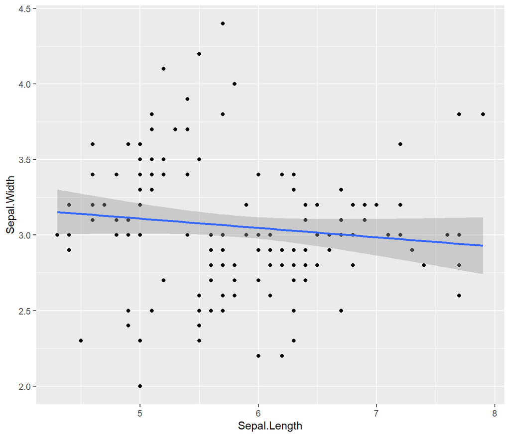

```r
ggplot(iris, aes(Sepal.Length, Sepal.Width)) +
  geom_point() +
  geom_smooth(method = 'lm')
```

- If $| r |$ > 0.9, there is multicollinearity.
- If r is too low, perform separate univariate ANOVA for each dependent variable.

# 6 Two-way MANOVA

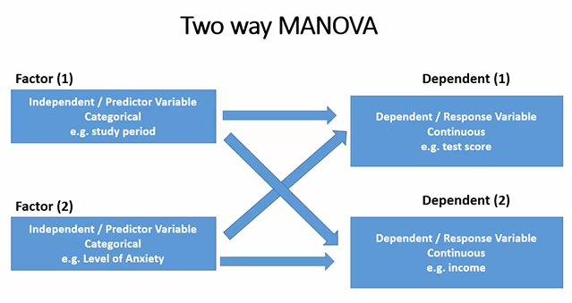

Multiple dependent numerical variables ~ two independent categorical variables

Example: Plastic. Do the rate of extrusion and the additive have influence on the plastic quality?

```r
data('Plastic', package = 'heplots')
Plastic_matrix <- as.matrix(Plastic[, c('tear','gloss','opacity')])
Plastic_manova <- manova(Plastic_matrix ~ Plastic$rate * Plastic$additive)
summary(Plastic_manova)
```

```
                              Df  Pillai approx F num Df den Df   Pr(>F)
Plastic$rate                   1 0.61814   7.5543      3     14 0.003034 **
Plastic$additive               1 0.47697   4.2556      3     14 0.024745 *
Plastic$rate:Plastic$additive  1 0.22289   1.3385      3     14 0.301782
Residuals                     16
---
Signif. codes:  0 '***' 0.001 '**' 0.01 '*' 0.05 '.' 0.1 ' ' 1
```

Each of the three response variables separately:

```r
summary.aov(Plastic_manova)
```

```
 Response tear :
                              Df Sum Sq Mean Sq F value   Pr(>F)
Plastic$rate                   1 1.7405 1.74050 15.7868 0.001092 **
Plastic$additive               1 0.7605 0.76050  6.8980 0.018330 *
Plastic$rate:Plastic$additive  1 0.0005 0.00050  0.0045 0.947143
Residuals                     16 1.7640 0.11025
---
Signif. codes:  0 '***' 0.001 '**' 0.01 '*' 0.05 '.' 0.1 ' ' 1

 Response gloss :
                              Df Sum Sq Mean Sq F value  Pr(>F)
Plastic$rate                   1 1.3005 1.30050  7.9178 0.01248 *
Plastic$additive               1 0.6125 0.61250  3.7291 0.07139 .
Plastic$rate:Plastic$additive  1 0.5445 0.54450  3.3151 0.08740 .
Residuals                     16 2.6280 0.16425
---
Signif. codes:  0 '***' 0.001 '**' 0.01 '*' 0.05 '.' 0.1 ' ' 1

 Response opacity :
                              Df Sum Sq Mean Sq F value Pr(>F)
Plastic$rate                   1  0.421  0.4205  0.1036 0.7517
Plastic$additive               1  4.901  4.9005  1.2077 0.2881
Plastic$rate:Plastic$additive  1  3.960  3.9605  0.9760 0.3379
Residuals                     16 64.924  4.0578
```

Conclusion: There are significant main effects for both rate and additive at $\alpha = 0.05$, but no interaction. The opacity is not significantly associated with either of the explanatory variables.

# 7 Further readings

- Applied Statistics for Environmental Science. Chapter 6
- https://www.r-bloggers.com/2021/11/manovamultivariate-analysis-of-variance-using-r/#google_vignette

# 8 Exercises

The iris dataset. Do the species have influence on the petal size? Carry out MANOVA with the post-hoc test and give your conclusion.